# Machine Learning Engineer Nanodegree

## Capstone Project

Yosuke Matsuno  
Oct 15st, 2018

# I. Definition

## Project Overview

#### NIKKEI225 MARKET PRICE PREDICTOR

Nowadays Machine learning technology applies to extensive industries. Especially it uses to core of trading in the finance industry. According to news website, Goldman Sachs replaced their 600 senior traders to 200 computer engineers and made automated trading system to use Machine learning technologies. This is a great example of it's capabilities. Statistical method was popular before but recently years Machine learning method are getting more prevalence.

Recently reports shows superiority to predict using Machine Learning.  
"Machine Learning with Financial Time Series Data on Google Cloud Platform"  
"A deep learning framework to financial time series using stacked autoencoders and long-short term memory"

I know stock market isn't closed world and always affected from various reasons(world political situation and so on). To predict future stock price is difficult challenge even big company like GS but I'm so interested in this field trend and feel motivate. So I will tackle to use these techniques and make my own way to get better prediction. I hope it would become my good investment solution to get daily beers:-)

#### - Reference -

Goldman Sachs Automated Trading Replaces 600 Traders With 200 Engineers  
https://developers.slashdot.org/story/17/02/07/225225/goldman-sachs-automated-trading-replaces-600-traders-with-200-engineers  
Machine Learning with Financial Time Series Data on Google Cloud Platform https://github.com/corrieelston/datalab/blob/master/FinancialTimeSeriesTensorFlow.ipynb  
A deep learning framework for financial time series using stacked autoencoders and long-short term memory  
https://journals.plos.org/plosone/article?id=10.1371/journal.pone.0180944

## Problem Statement

The purpose of this capstone project is to build great machine learning model that can predict future stock price using historical data input. There are two type of problems. To predict future stock price is regression problem and to predict future stock price is higher or lower than today is classification problem. This project I will focus to solve regression problem to predict future stock price.

#### - Correction -

I did mistyping about previous proporsal.

WRONG: This project I will focus to solve **classification** problem to predict future stock price.  
NEW: This project I will focus to solve **regression** problem to predict future stock price.

## Metrics

Root mean squared error is good evaluation metrics to regression problem. RMSE can easy to measure what is the average deviation of the prediction from the true price and it can be compared with the mean of the true value to see whether the deviation is large or small.

# II. Analysis

## Data Exploration

#### Historical Nikkei225

Input csv data contains with "Date", "Open", "High", "Low", "Close", "Volume" about Nikkei225 market which has 1 day period from 2000 - 2018.

```python
import pandas as pd
import numpy as np

pd.set_option("display.width", 100)
pd.set_option("display.max_rows", 200)

file = "/Users/Graph/-Work-/Local_Dev/Udacity - Machine Learning Nanodegree/Part7 - Machine Learning Capstone/P2 - Machine Learning Capstone Project/submit1/Nikkei225_1day_20000831-20180831.csv"
nikkei_ohlc = pd.read_csv(file)
nikkei_ohlc = nikkei_ohlc.dropna()
nikkei_ohlc = nikkei_ohlc.drop(["Adj Close"], axis= 1)
nikkei_ohlc["Date"] = pd.to_datetime(nikkei_ohlc["Date"])

nikkei_ohlc["Open"] = nikkei_ohlc["Open"].astype(np.int64)
nikkei_ohlc["High"] = nikkei_ohlc["High"].astype(np.int64)
nikkei_ohlc["Low"] = nikkei_ohlc["Low"].astype(np.int64)
nikkei_ohlc["Close"] = nikkei_ohlc["Close"].astype(np.int64)
nikkei_ohlc = nikkei_ohlc.set_index("Date")
```

```python
nikkei_ohlc.head()
```

| Date | Open | High | Low | Close | Volume |
| --- | --- | --- | --- | --- | --- |
| 2000-08-31 | 16918 | 17056 | 16769 | 16861 | 0.0 |
| 2000-09-01 | 16915 | 17018 | 16700 | 16739 | 0.0 |
| 2000-09-04 | 16764 | 16883 | 16661 | 16688 | 0.0 |
| 2000-09-05 | 16677 | 16712 | 16401 | 16452 | 0.0 |
| 2000-09-06 | 16433 | 16531 | 16364 | 16399 | 0.0 |

```python
nikkei_ohlc.tail()
```

| Date | Open | High | Low | Close | Volume |
| --- | --- | --- | --- | --- | --- |
| 2018-08-24 | 22484 | 22602 | 22452 | 22601 | 50400.0 |
| 2018-08-27 | 22693 | 22838 | 22682 | 22799 | 50200.0 |
| 2018-08-28 | 22967 | 23006 | 22813 | 22813 | 60700.0 |
| 2018-08-29 | 22820 | 22968 | 22819 | 22848 | 58800.0 |
| 2018-08-30 | 23020 | 23032 | 22832 | 22869 | 73900.0 |

```python
nikkei_ohlc.describe()
```

|  | Open | High | Low | Close | Volume |
| --- | --- | --- | --- | --- | --- |
| count | 4418.000000 | 4418.000000 | 4418.000000 | 4418.000000 | 4418.000000 |
| mean | 13545.876188 | 13631.268900 | 13452.465595 | 13541.709371 | 113969.013128 |
| std | 4027.245245 | 4037.648377 | 4014.724234 | 4028.025319 | 62181.731417 |
| min | 7059.000000 | 7100.000000 | 6994.000000 | 7054.000000 | 0.000000 |
| 25% | 10096.000000 | 10149.000000 | 10030.750000 | 10083.750000 | 77425.000000 |
| 50% | 12861.000000 | 13002.000000 | 12781.500000 | 12848.500000 | 117200.000000 |
| 75% | 16557.500000 | 16663.000000 | 16451.500000 | 16551.000000 | 147500.000000 |
| max | 24078.000000 | 24129.000000 | 23917.000000 | 24124.000000 | 595200.000000 |

## Exploratory Visualization

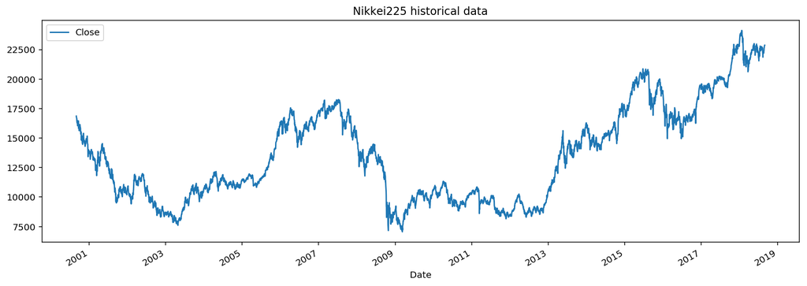

```python
%matplotlib inline
%config InlineBackend.figure_format = "retina"
import matplotlib.pyplot as plt

nikkei_ohlc["Close"].plot(figsize=(15, 5), title= "Nikkei225 historical data", legend= True)
```

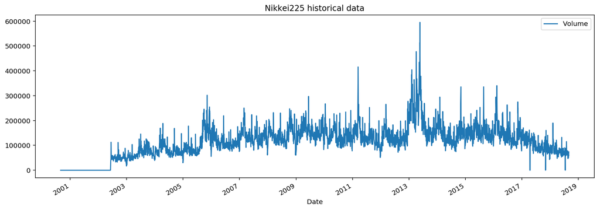

```python
nikkei_ohlc["Volume"].plot(figsize=(15, 5), title= "Nikkei225 historical data", legend= True)
```

## Algorithms and Techniques

I chose to use Long Short Term Memory recurrent neural networks to this regression problem. Because input data is time sequencial data. So LSTM RNNs can be fit to solve regression problem. This trained model will be able to predict future price from specific time range input until today. (for example (n) days input returns next day predicted price.)

## Benchmark

I chose Linear Regression as benchmark model to compare performance with LSTM. Linear Regression is still effective model for various problems. So I think easy to measure the difference of each performance.

# III. Methodology

### My simple strategy for profit

Assuming trained model can predict next day close price correctly.

**IF** predicted price is **Higher** than "close" price => **BUY** stock and **SELL** end of the day.  
**ElIF** predict price is **Lower** than "close" price => **SELL** stock and **BUY** end of the day.

## Implementation

### Add extra features

**Result**: Next day close price. (true price for prediction)  
**Variation_rate**: How increase or decrease price during the day.

```python
nikkei_ohlc["Result"] = nikkei_ohlc["Close"].shift(-1)
nikkei_ohlc["Variation"] = nikkei_ohlc["Close"] - nikkei_ohlc["Open"]
nikkei_ohlc["Variation_rate"] = (nikkei_ohlc["Close"] - nikkei_ohlc["Open"]) / nikkei_ohlc["Close"]
nikkei_ohlc = nikkei_ohlc.dropna()
```

```python
nikkei_ohlc.head()
```

| Date | Open | High | Low | Close | Volume | Result | Variation | Variation_rate |
| --- | --- | --- | --- | --- | --- | --- | --- | --- |
| 2000-08-31 | 16918 | 17056 | 16769 | 16861 | 0.0 | 16739.0 | -57 | -0.003381 |
| 2000-09-01 | 16915 | 17018 | 16700 | 16739 | 0.0 | 16688.0 | -176 | -0.010514 |
| 2000-09-04 | 16764 | 16883 | 16661 | 16688 | 0.0 | 16452.0 | -76 | -0.004554 |
| 2000-09-05 | 16677 | 16712 | 16401 | 16452 | 0.0 | 16399.0 | -225 | -0.013676 |
| 2000-09-06 | 16433 | 16531 | 16364 | 16399 | 0.0 | 16300.0 | -34 | -0.002073 |

### Split training-test and validation dataset

```python
ohlc_train_test = nikkei_ohlc.copy()
ohlc_train_test = ohlc_train_test["2001" : "2015"]
ohlc_validation = nikkei_ohlc.copy()
ohlc_validation = ohlc_validation["2015" : "2018"]
```

### [ Linear Regression (as benchmark) ]

### 1. Normalization and clean dataset

```python
mean = ohlc_train_test['Close'].mean()

ohlc_train_test['Close'] = ohlc_train_test['Close'] / mean
ohlc_train_test['Result'] = ohlc_train_test['Result'] / mean
ohlc_train_test['Variation'] = ohlc_train_test['Variation'] / mean

ohlc_validation['Close'] = ohlc_validation['Close'] / mean
ohlc_validation['Result'] = ohlc_validation['Result'] / mean
ohlc_validation['Variation'] = ohlc_validation['Variation'] / mean
```

### 2. Split training and test dataset

```python
from sklearn.model_selection import train_test_split

def generate_LR_dataset(ohlc, columns_input, train_size):

    X_train, X_test, y_train, y_test = train_test_split(ohlc[columns_input],
                                                        ohlc["Result"],
                                                        random_state= 0,
                                                        stratify= None,
                                                        shuffle= False,
                                                        test_size= (1 - train_size))
    return X_train, X_test, y_train, y_test
```

```python
columns_input = ["Open", "High", "Low", "Close", "Variation", "Variation_rate"]
LR_dataset = generate_LR_dataset(ohlc_train_test, columns_input, 0.8)
X_train, X_test, y_train, y_test = LR_dataset[0], LR_dataset[1], LR_dataset[2], LR_dataset[3]
```

### 3. Build Linear Regression model

```python
from sklearn.linear_model import LinearRegression
import numpy as np

LR_model = LinearRegression()
LR_model.fit(X_train, y_train)
```

```
LinearRegression(copy_X=True, fit_intercept=True, n_jobs=1, normalize=False)
```

### 4. Predict

```python
y_pred = LR_model.predict(X_test)
```

### 5. Evaluation

```python
from sklearn.metrics import mean_squared_error

rmse = np.sqrt(mean_squared_error(y_test, y_pred))
```

```python
"RMSE: {}".format(rmse)
```

```
'RMSE: 0.018162128564570106'
```

```python
ohlc_train_test["Absolute_Variation"] = abs(ohlc_train_test["Variation"])
"Variation Average: {}".format(ohlc_train_test["Absolute_Variation"].mean())
```

```
'Variation Average: 0.00783088281773196'
```

### 6. Visualize predict

```python
X_test["Result"] = y_test
X_test["Predict"] = y_pred
```

```python
X_test.head()
```

| Date | Open | High | Low | Close | Variation | Variation_rate | Result | Predict |
| --- | --- | --- | --- | --- | --- | --- | --- | --- |
| 2012-12-26 | 10131 | 10230 | 10107 | 0.822750 | 0.007962 | 0.009677 | 0.830149 | 0.821973 |
| 2012-12-27 | 10295 | 10376 | 10288 | 0.830149 | 0.002171 | 0.002616 | 0.836020 | 0.830172 |
| 2012-12-28 | 10406 | 10433 | 10374 | 0.836020 | -0.000885 | -0.001058 | 0.859585 | 0.835729 |
| 2013-01-04 | 10604 | 10734 | 10602 | 0.859585 | 0.006756 | 0.007859 | 0.852427 | 0.859419 |
| 2013-01-07 | 10743 | 10743 | 10589 | 0.852427 | -0.011581 | -0.013586 | 0.845108 | 0.853154 |

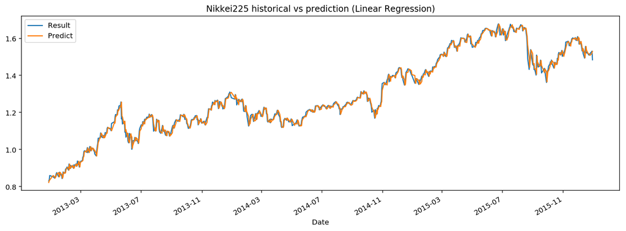

```python
X_test["Result"].plot(figsize=(15, 5), title= "Nikkei225 historical vs prediction (Linear Regression)", legend= True)
X_test["Predict"].plot(figsize=(15, 5), title= "Nikkei225 historical vs prediction (Linear Regression)", legend= True)
```

**Close up**

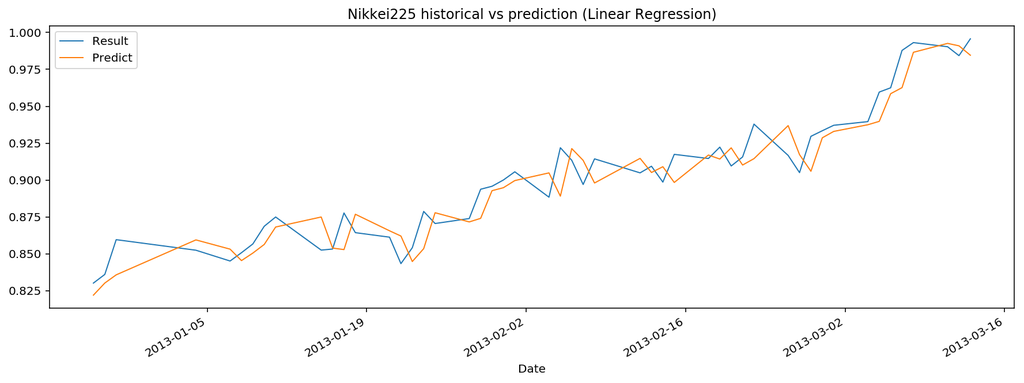

```python
X_test_crop = X_test[0 : 50]

X_test_crop["Result"].plot(figsize=(15, 5), linewidth= 1, title= "Nikkei225 historical vs prediction (Linear Regression)", legend= True)
X_test_crop["Predict"].plot(figsize=(15, 5), linewidth= 1, title= "Nikkei225 historical vs prediction (Linear Regression)", legend= True)
```

### 7. Strategy simulation

```python
good_predict = 0

for index in range(len(X_test)):
    val = X_test["Result"][index] - X_test["Close"][index]
    val_pred = X_test["Predict"][index] - X_test["Close"][index]

    if val > 0 and val_pred > 0 or val < 0 and val_pred < 0:
        good_predict += 1

print ("Total Trade: {} Good: {} Bad: {}".format(len(X_test), good_predict, (len(X_test)-good_predict)))
print ("Predict Accuracy: {}%".format(good_predict/len(X_test)*100))
```

```
Total Trade: 736 Good: 366 Bad: 370
Predict Accuracy: 49.72826086956522%
```

### Split training-test and validation dataset

```python
ohlc_train_test = nikkei_ohlc.copy()
ohlc_train_test = ohlc_train_test["2001" : "2015"]
ohlc_validation = nikkei_ohlc.copy()
ohlc_validation = ohlc_validation["2015" : "2018"]
```

### 1. Normalization and clean dataset

```python
mean = ohlc_train_test['Close'].mean()

ohlc_train_test['Close'] = ohlc_train_test['Close'] / mean
ohlc_train_test['Result'] = ohlc_train_test['Result'] / mean
ohlc_train_test['Variation'] = ohlc_train_test['Variation'] / mean
ohlc_train_test = ohlc_train_test.drop(["Open", "High", "Low", "Volume", "Variation_rate"], axis= 1)

ohlc_validation['Close'] = ohlc_validation['Close'] / mean
ohlc_validation['Result'] = ohlc_validation['Result'] / mean
ohlc_validation['Variation'] = ohlc_validation['Variation'] / mean
ohlc_validation = ohlc_validation.drop(["Open", "High", "Low", "Volume", "Variation_rate"], axis= 1)
```

### 2. make dataset: (n) days historical price list and next day price

```python
import numpy as np

def generate_lstm_dataset(ohlc, period_day, overlap= False):

    stock_price = []
    result_price = []

    # avoid overlap
    if overlap == False:
        for index in range(0, len(ohlc)-period_day, period_day):
            stock_price.append(ohlc["Close"][index : index+period_day].values)
            result_price.append(ohlc["Close"][index+period_day])
    else:
        for index in range(len(ohlc)-period_day):
            stock_price.append(ohlc["Close"][index : index+period_day].values)
            result_price.append(ohlc["Close"][index+period_day])

    stock_price = np.array(stock_price)

    return {"stock_price": stock_price, "result_price": result_price}
```

```python
period_day = 30

LSTM_dataset = generate_lstm_dataset(ohlc_train_test, period_day)
stock_price, result_price = LSTM_dataset["stock_price"], LSTM_dataset["result_price"]
```

```python
print ("stock_price: {} result_price: {}".format(len(stock_price), len(result_price)))
```

```
stock_price: 122 result_price: 122
```

### 3. Split training and test data set

```python
train_size = 0.8

X_train = stock_price[0 : int(train_size*len(stock_price))]
y_train = result_price[0 : int(train_size*len(result_price))]

X_test = stock_price[int(train_size*len(stock_price)) :]
y_test = result_price[int(train_size*len(result_price)) :]

# adjust shape
a, b = X_train.shape
X_train = X_train.reshape(a, b , 1)

a, b = X_test.shape
X_test = X_test.reshape(a, b , 1)
```

### 4. Build LSTM model

```python
from keras.models import Sequential
from keras.layers.core import Dense, Activation, Dropout
from keras.layers.recurrent import LSTM

in_out_neurons = 1
hidden_neurons = 200
length_of_sequences = period_day

LSTM_model = Sequential()

LSTM_model.add(LSTM(hidden_neurons, batch_input_shape= (None, length_of_sequences, in_out_neurons), return_sequences= False))
LSTM_model.add(Dropout(0.2))
LSTM_model.add(Dense(in_out_neurons))
LSTM_model.add(Activation("linear"))
```

```python
LSTM_model.compile(loss= "mean_squared_error", optimizer= "adam")
history = LSTM_model.fit(X_train, y_train, batch_size= 600, epochs= 100, validation_split= 0.2)
```

```
Train on 77 samples, validate on 20 samples
```

### 5. Learning Curve

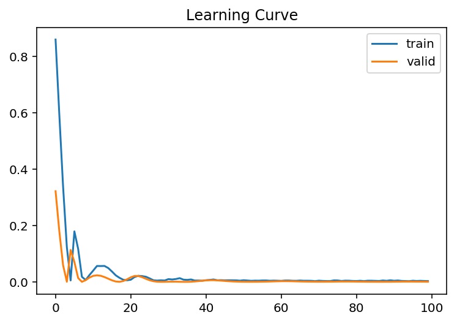

```python
plt.plot(history.history['loss'], label='train')
plt.plot(history.history['val_loss'], label='valid')
plt.title("Learning Curve")
plt.legend()
```

### 6. Predict

```python
y_pred = LSTM_model.predict(X_test)
```

### 7. Evaluation

```python
from sklearn.metrics import mean_squared_error

rmse = np.sqrt(mean_squared_error(y_test, y_pred))
```

```python
"RMSE: {}".format(rmse)
```

```
'RMSE: 0.04061575188644332'
```

```python
ohlc_train_test["Absolute_Variation"] = abs(ohlc_train_test["Variation"])
"Variation Average: {}".format(ohlc_train_test["Absolute_Variation"].mean())
```

```
'Variation Average: 0.00783088281773196'
```

### 8. Visualize predict result

```python
tmp = (X_test[:, -1])

close = []
for index in range(len(tmp)):
    close.append(tmp[index][0])
```

```python
LSTM_result =  pd.DataFrame()

LSTM_result["Close"] = close
LSTM_result["Result"] = y_test
LSTM_result["Predict"] = y_pred
```

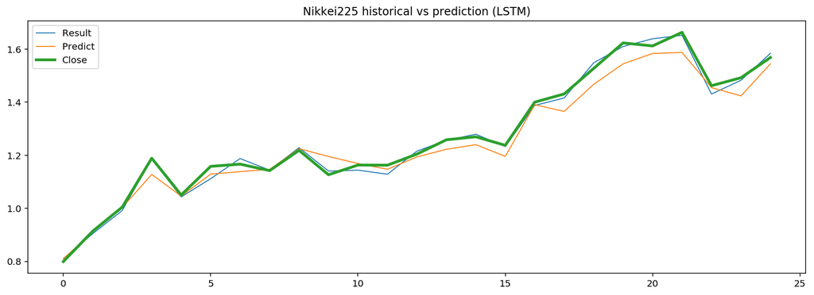

```python
LSTM_result["Result"].plot(figsize=(15, 5), linewidth= 1, title= "Nikkei225 historical vs prediction (LSTM)", legend= True)
LSTM_result["Predict"].plot(figsize=(15, 5), linewidth= 1, title= "Nikkei225 historical vs prediction (LSTM)", legend= True)
LSTM_result["Close"].plot(figsize=(15, 5), linewidth= 3, title= "Nikkei225 historical vs prediction (LSTM)", legend= True)
```

**Close up**

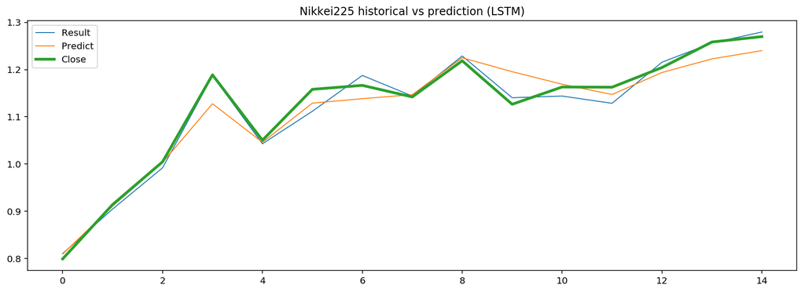

```python
LSTM_result_crop = LSTM_result[0:15]
LSTM_result_crop["Result"].plot(figsize=(15, 5), linewidth= 1, title= "Nikkei225 historical vs prediction (LSTM)", legend= True)
LSTM_result_crop["Predict"].plot(figsize=(15, 5), linewidth= 1, title= "Nikkei225 historical vs prediction (LSTM)", legend= True)
LSTM_result_crop["Close"].plot(figsize=(15, 5), linewidth= 3, title= "Nikkei225 historical vs prediction (LSTM)", legend= True)
```

### 9. Strategy simulation

```python
good_predict = 0
for index in range(len(LSTM_result)):
    val = LSTM_result["Result"][index] - LSTM_result["Close"][index]
    val_pred = LSTM_result["Predict"][index] - LSTM_result["Close"][index]

    if val > 0 and val_pred > 0 or val < 0 and val_pred < 0:
        good_predict += 1

print ("Total Trade: {} Good: {} Bad: {}".format(len(X_test), good_predict, (len(X_test)-good_predict)))
print ("Predict Accuracy: {}%".format(good_predict/len(X_test)*100))
```

```
Total Trade: 25 Good: 18 Bad: 7
Predict Accuracy: 72.0%
```

Woow! it seems great:-)!

### 10. Varidation

```python
LSTM_vadil_dataset = generate_lstm_dataset(ohlc_validation, period_day, overlap= True)
stock_price, result_price = LSTM_vadil_dataset["stock_price"], LSTM_vadil_dataset["result_price"]
```

```python
X_test = stock_price
y_test = result_price

# adjust shape
a, b = X_test.shape
X_test = X_test.reshape(a, b , 1)
```

```python
y_pred = LSTM_model.predict(X_test)
```

```python
from sklearn.metrics import mean_squared_error

rmse2 = np.sqrt(mean_squared_error(y_test, y_pred))
```

```python
"RMSE: {}".format(rmse2)
```

```
'RMSE: 0.06538149200971635'
```

```python
ohlc_validation["Absolute_Variation"] = abs(ohlc_validation["Variation"])
"Variation Average: {}".format(ohlc_validation["Absolute_Variation"].mean())
```

```
'Variation Average: 0.009220156968705021'
```

### 11. Visualize predict result

```python
tmp = (X_test[:, -1])

close = []
for index in range(len(tmp)):
    close.append(tmp[index][0])
```

```python
LSTM_result = pd.DataFrame()

LSTM_result["Close"] = close
LSTM_result["Result"] = y_test
LSTM_result["Predict"] = y_pred
```

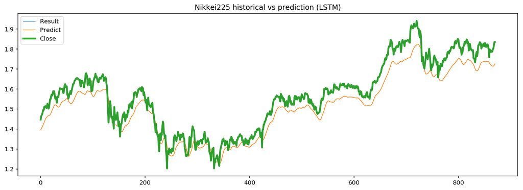

```python
LSTM_result["Result"].plot(figsize=(15, 5), linewidth= 1,title= "Nikkei225 historical vs prediction (LSTM)", legend= True)
LSTM_result["Predict"].plot(figsize=(15, 5), linewidth= 1,title= "Nikkei225 historical vs prediction (LSTM)", legend= True)
LSTM_result["Close"].plot(figsize=(15, 5), linewidth= 3, title= "Nikkei225 historical vs prediction (LSTM)", legend= True)
```

**Close up**

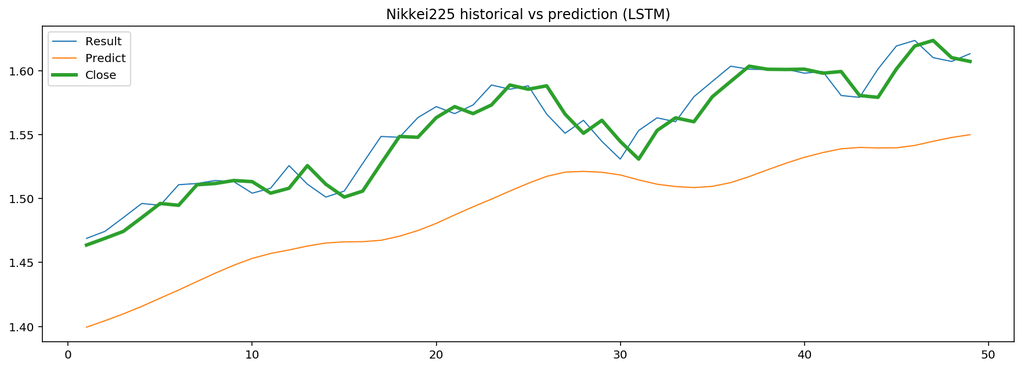

```python
LSTM_result_crop = LSTM_result[1 : 50]
LSTM_result_crop["Result"].plot(figsize=(15, 5), linewidth= 1,title= "Nikkei225 historical vs prediction (LSTM)", legend= True)
LSTM_result_crop["Predict"].plot(figsize=(15, 5), linewidth= 1,title= "Nikkei225 historical vs prediction (LSTM)", legend= True)
LSTM_result_crop["Close"].plot(figsize=(15, 5), linewidth= 3, title= "Nikkei225 historical vs prediction (LSTM)", legend= True)
```

### 12. Strategy simulation

```python
good_predict = 0

for index in range(len(LSTM_result)):
    val = LSTM_result["Result"][index] - LSTM_result["Close"][index]
    val_pred = LSTM_result["Predict"][index] - LSTM_result["Close"][index]

    if val > 0 and val_pred > 0 or val < 0 and val_pred < 0:
        good_predict += 1

print ("Total Trade: {} Good: {} Bad: {}".format(len(X_test), good_predict, (len(X_test)-good_predict)))
print ("Predict Accuracy: {}%".format(good_predict/len(X_test)*100))
```

```
Total Trade: 871 Good: 411 Bad: 460
Predict Accuracy: 47.18714121699196%
```

Uhh not great at all:-(

### [ LTSM RNN V2 ] predict continous output

```python
ohlc_train_test = nikkei_ohlc.copy()
ohlc_train_test = ohlc_train_test["2001" : "2015"]
ohlc_validation = nikkei_ohlc.copy()
ohlc_validation = ohlc_validation["2015" : "2018"]
```

### 1. Normalization and clean dataset

```python
mean = ohlc_train_test['Close'].mean()

ohlc_train_test['Close'] = ohlc_train_test['Close'] / mean
ohlc_train_test['Result'] = ohlc_train_test['Result'] / mean
ohlc_train_test['Variation'] = ohlc_train_test['Variation'] / mean
ohlc_train_test = ohlc_train_test.drop(["Open", "High", "Low", "Volume", "Variation_rate"], axis= 1)

ohlc_validation['Close'] = ohlc_validation['Close'] / mean
ohlc_validation['Result'] = ohlc_validation['Result'] / mean
ohlc_validation['Variation'] = ohlc_validation['Variation'] / mean
ohlc_validation = ohlc_validation.drop(["Open", "High", "Low", "Volume", "Variation_rate"], axis= 1)
```

### 2. make dataset: (n) days historical price list and next day price

```python
period_day = 20
```

```python
LSTM_dataset = generate_lstm_dataset(ohlc_train_test, period_day, overlap= False)
stock_price, result_price = LSTM_dataset["stock_price"], LSTM_dataset["result_price"]
```

```python
print ("stock_price: {} result_price: {}".format(len(stock_price), len(result_price)))
```

```
stock_price: 183 result_price: 183
```

### 3. Split training and test data set

```python
train_size = 0.8

X_train = stock_price[0 : int(train_size*len(stock_price))]
y_train = result_price[0 : int(train_size*len(result_price))]

X_test = stock_price[int(train_size*len(stock_price)) :]
y_test = result_price[int(train_size*len(result_price)) :]

# adjust shape
a, b = X_train.shape
X_train = X_train.reshape(a, b , 1)

a, b = X_test.shape
X_test = X_test.reshape(a, b , 1)
```

### 4. Build LSTM model

```python
import os
import time
import warnings
import numpy as np
from numpy import newaxis
from keras.layers.core import Dense, Activation, Dropout
from keras.layers.recurrent import LSTM
from keras.models import Sequential
warnings.filterwarnings("ignore")

LSTM_model_v2 = Sequential()
LSTM_model_v2.add(LSTM(input_shape= (period_day, 1),
               output_dim= 100,
               return_sequences= True))

LSTM_model_v2.add(Dropout(0.2))
LSTM_model_v2.add(LSTM(100, return_sequences= False))
LSTM_model_v2.add(Dropout(0.2))
LSTM_model_v2.add(Dense(output_dim= 1))
LSTM_model_v2.add(Activation("linear"))
LSTM_model_v2.compile(loss="mse", optimizer= "rmsprop")
```

```python
history = LSTM_model_v2.fit(X_train, y_train, batch_size= 512, nb_epoch= 50, validation_split= 0.05)
```

```
Train on 138 samples, validate on 8 samples
```

### 5. Learning Curve

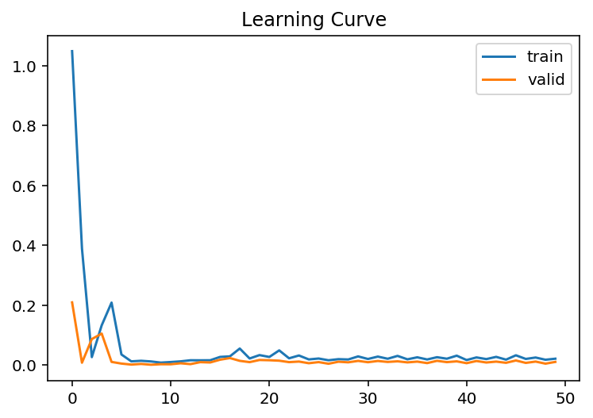

```python
plt.plot(history.history['loss'], label='train')
plt.plot(history.history['val_loss'], label='valid')
plt.title("Learning Curve")
plt.legend()
```

### 6. Predict

```python
predict_day = 10
```

```python
y_pred = []

for index in range(int(len(X_test) / predict_day)):
    current_frame = X_test[index * predict_day]
    predicted = []
    for day in range(predict_day):
        predicted.append(LSTM_model_v2.predict(current_frame[newaxis,:,:])[0,0])
        current_frame = current_frame[1:]
        current_frame = np.insert(current_frame, [period_day-1], predicted[-1], axis= 0)
    y_pred.append(predicted)
```

### 7. Visualize predict

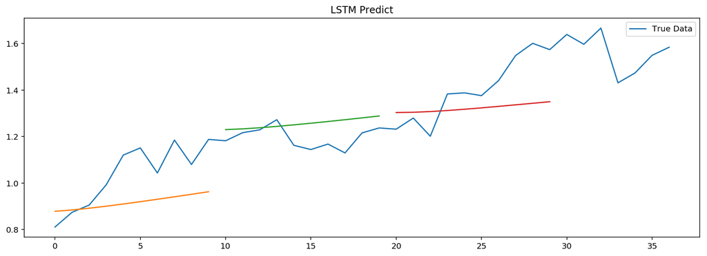

```python
fig = plt.figure(figsize= (15, 5))
ax = fig.add_subplot(111)

ax.plot(y_test, label= "True Data")
for index, data in enumerate(y_pred):
    padding = [None for p in range(index * predict_day)]
    plt.plot(padding + data)
plt.title("LSTM Predict")
plt.legend()
```

Woow it seems that LSTM model can catch market behavior! Go to Validation:-)

### 7. Varidation

```python
LSTM_vadil_dataset = generate_lstm_dataset(ohlc_validation, period_day, overlap= False)
stock_price, result_price = LSTM_vadil_dataset["stock_price"], LSTM_vadil_dataset["result_price"]
```

```python
X_test = stock_price
y_test = result_price

# adjust shape
a, b = X_test.shape
X_test = X_test.reshape(a, b , 1)
```

### 8. Predict

```python
y_pred = []

for index in range(int(len(X_test) / predict_day)):
    current_frame = X_test[index * predict_day]
    predicted = []
    for day in range(predict_day):
        predicted.append(LSTM_model_v2.predict(current_frame[newaxis,:,:])[0,0])
        current_frame = current_frame[1:]
        current_frame = np.insert(current_frame, [period_day-1], predicted[-1], axis= 0)
    y_pred.append(predicted)
```

### 9. Visualize predict

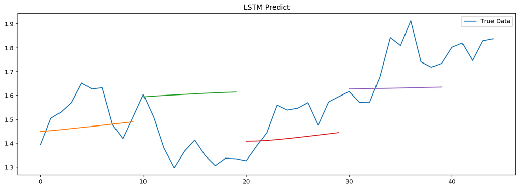

```python
fig = plt.figure(figsize= (15, 5))
ax = fig.add_subplot(111)

ax.plot(y_test, label= "True Data")
for index, data in enumerate(y_pred):
    padding = [None for p in range(index * predict_day)]
    plt.plot(padding + data)
plt.title("LSTM Predict")
plt.legend()
```

Uhh still need tune up:-(.

## Refinement

#### Features and parameters

- Adding features  
  "Variation_rate" which represent how increase or decrease price during the day.
- Normalize parameter  
  Normalization is many ways to do and I did divided by mean value this time. Relative value is more effective for making better model not only absolute value like close price.

#### Hyper parameter

- LSTM  
  Still need deep understanding about each parameter but I was trying to find nice balance between calcutation time and prediction result.  
  Continous output seem kinds of possibility but need more time to tune up.

# IV. Results

## Model Evaluation and Validation

### Model Choice

**[ Linear Regression ]**

RMSE: 0.0181 Variation Average: 0.0078

**strategy result**  
Total Trade: 736 Good: 366 Bad: 370  
Predict Accuracy: 49.7%

## Justification

Both of Linear Regression RSME and LST score are not good and still huge gap compare to actual price. But I found even though LSTM doesn't predict true price perfectly but according to continous output result, LSTM seems can predict something about market behavior.

The LSTM seems reasonable solution to solve regression problem if I could tune up more.

# V. Conclusion

## Reflection

#### Found Interesting

Prediction result changed dramalically depends on feature selection and algorithm. It's so fun and I cloud feel possibility about LSTM algorithm. I'm still checking and tuning about my LSTM model.

#### Found difficult

It was so hard to find proper way to use and selection of each algorithms and parameters also how to avoid overfit. Method should change depends on dataset every time and it was like a endless try and error. I felt that I need more deep understanding and experience about LSTM and even Linear Regression.

#### Next improvement and challenge

I chose LSTM as a core algorithm in this project.  
But I know there are a lot of different algorithms to solve.

I'm interested in and will try.

- Convolutional Nural Network  
  https://lucenaresearch.com/timeseries-convolutional/
- Deep Reinforcement Learning  
  https://medium.com/@gaurav1086/machine-learning-for-algorithmic-trading-f79201c8bac6

I am also interested in the difference of performance compared to the classification problem.  
It's good challenge to combine with sentiment analysis result from SNS like twitter and news website to get even better prediction as well.

It seems endless challenges but I have endless motivation. So I will continue to learning:-)

## Reference

I was struggling to understandnad about using LTSM. This website helped me a lot.

Stock Market Predictions with LSTM in Python https://www.datacamp.com/community/tutorials/lstm-python-stock-market